# Análise Exploratória InfraWatch

Equipe InfraWatch

## Como os dados fundamentam as métricas e visualizações das dashboards

### 1. Carregar a amostra e conferir a qualidade

```
         HOSTNAME           TIMESTAMP  CPU  RAM DISCO QTD-PROCESSOS
  LAPTOP-TQPP5J6D 2026-10-05 04:56:37  8.3 87.2  90.2           281
  LAPTOP-TQPP5J6D 2026-10-05 04:56:39 12.6 87.1  90.2           281
  LAPTOP-TQPP5J6D 2026-10-05 04:56:41 26.4 87.2  90.2           280
  LAPTOP-TQPP5J6D 2026-10-05 04:56:43 16.9 87.0  90.2           280
  LAPTOP-TQPP5J6D 2026-10-05 04:56:46 12.6 87.1  90.2           280
  LAPTOP-TQPP5J6D 2026-10-05 04:56:48 10.3 87.3  90.2           280
  LAPTOP-TQPP5J6D 2026-10-05 04:56:50 12.6 87.2  90.2           280
  LAPTOP-TQPP5J6D 2026-10-05 04:56:52 15.4 86.6  90.2           280
  LAPTOP-TQPP5J6D 2026-10-05 04:56:54  9.0 86.7  90.2           280
```

```
Quantidade de registros: 9
```

```
Quantidade de equipamentos: 1
```

```
Duração entre a primeira e a última captura (segundos): 17
```

```
Intervalos entre capturas (segundos): 2s 2s 2s 3s 2s 2s 2s 2s
```

#### Leitura da amostra

São **9 registros de um único notebook**, em 05/10/2026, entre 04:56:37 e 04:56:54: uma janela de **17 segundos**, com intervalos de 2 ou 3 segundos. Não há valores ausentes nem duplicações da combinação equipamento/instante na amostra.

As medições consecutivas podem depender umas das outras. Por isso, esta análise é descritiva: não representa um dia de operação, outros equipamentos ou toda a infraestrutura. CPU e RAM são percentuais de utilização; **DISCO é ocupação de armazenamento, não velocidade de leitura/escrita**.

O arquivo `processos_ativos.csv` não será cruzado com as capturas: ele não possui timestamp por registro e não informa consumo de CPU/RAM por processo. Assim, não podemos atribuir um pico a um programa específico.

### 2. Indicadores que podemos calcular

Os cards da dashboard específica mostram a **última medição**, e não a média de toda a janela. A tabela abaixo mantém essa distinção. Média e mediana ajudam a interpretar os gráficos históricos; mínimo, máximo e desvio padrão descrevem a variação.

O desvio padrão está em **pontos percentuais (p.p.)**. Para disco, o espaço disponível percentual é `100 - uso`, sem converter esse valor em GB.

```
##  Componente Ultimo_percentual Media_percentual Mediana_percentual
##         CPU               9.0            13.79               12.6
##         RAM              86.7            87.04               87.1
##       DISCO              90.2            90.20               90.2
##  Minimo_percentual Maximo_percentual Desvio_padrao_pp
##                8.3              26.4             5.49
##               86.6              87.3             0.24
##               90.2              90.2             0.00
```

```
##
## Espaço disponível na última captura (%): 9.8
```

```
##
## Quantidade de processos: mínimo = 280 e máximo = 281
```

#### Interpretação dos indicadores

Na última captura, os cards calculados com esta amostra seriam **CPU 9,0%**, **RAM 86,7%**, **disco ocupado 90,2%** e **disponível 9,8%**. A média da CPU, porém, foi **13,79%** e o máximo **26,4%**: olhar somente o último valor esconderia o pico registrado anteriormente.

A RAM apresentou média de **87,04%** e o disco permaneceu em **90,2%**. Esses resultados justificam acompanhar os componentes separadamente: uma CPU com baixo uso não significa que memória e armazenamento também estejam com baixa ocupação. A quantidade de processos ficou entre 280 e 281, mas essa contagem não explica sozinha o consumo dos recursos.

### 3. Histogramas — em quais faixas os consumos se concentram?

Um histograma conta quantas capturas ficaram em cada faixa de utilização. A linha vermelha indica a média e a azul indica a mediana. Os eixos de RAM e disco foram ampliados para mostrar os valores desta janela; essa escala reduzida não significa grande variação operacional.

#### 3.1 CPU

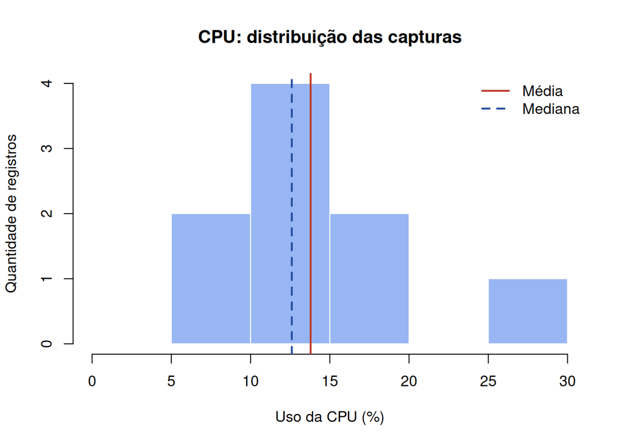

**Análise:** quatro das nove capturas ficaram na faixa acima de 10% até 15%, e houve um valor na faixa acima de 25% até 30%. A média de 13,79% ficou acima da mediana de 12,6%, influenciada pelo pico de 26,4%. Não há evidência de CPU próxima de sua capacidade máxima nesta janela.

**Utilidade na dashboard:** o card informa o uso atual; o histórico de CPU permite verificar se um valor alto é pontual ou repetido. O histograma fundamenta essa leitura da frequência dos níveis de consumo, mas não mostra a ordem temporal do pico.

#### 3.2 RAM

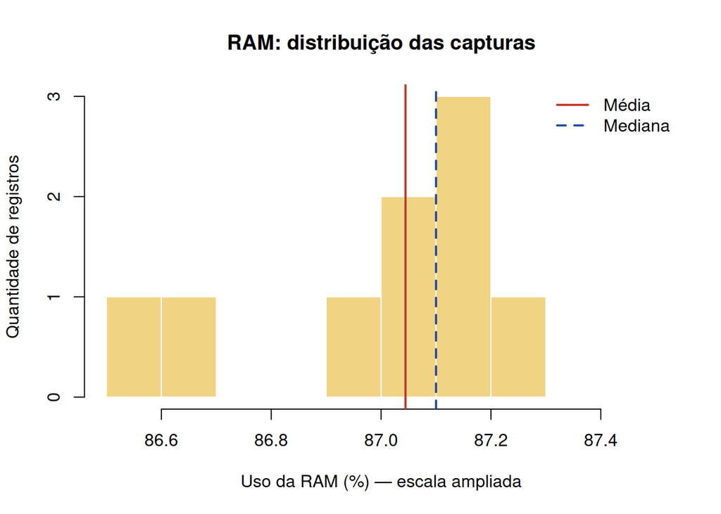

**Análise:** os valores de RAM ficaram entre 86,6% e 87,3%, uma amplitude de apenas **0,7 p.p.**, com média de 87,04%. A memória permaneceu com ocupação alta em relação à capacidade total, mesmo sem grandes oscilações. Isso, isoladamente, não comprova falta de memória, lentidão ou necessidade de expansão.

**Utilidade na dashboard:** justifica um card e um histórico próprios para RAM. A ausência de picos não dispensa o acompanhamento de um consumo continuamente elevado. A classificação operacional deve considerar o limite configurado e medições por um período maior, não somente o formato do histograma.

#### 3.3 Disco

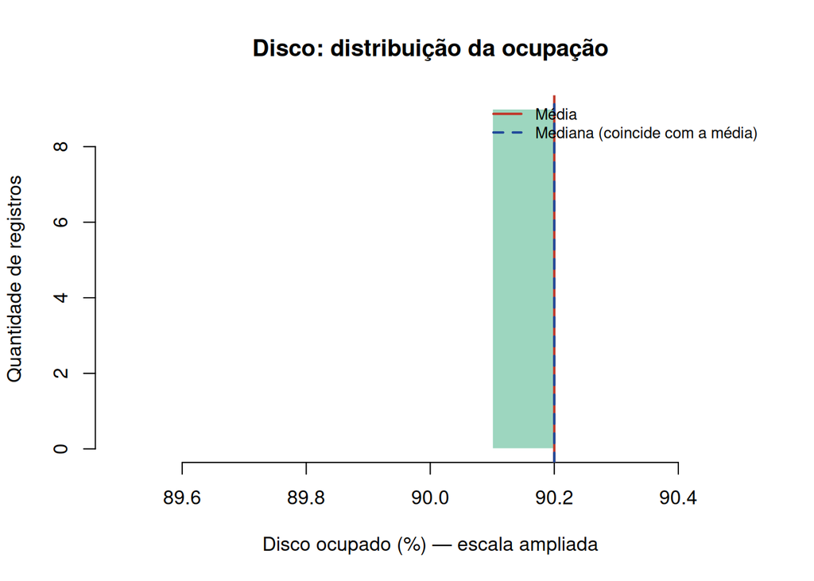

```r
hist(dados$DISCO, breaks = seq(89.5, 90.5, by = 0.1),
     main = "Disco: distribuição da ocupação", xlab = "Disco ocupado (%) — escala ampliada",
     ylab = "Quantidade de registros", col = "#9DD6BF", border = "white")
abline(v = mean(dados$DISCO), col = "#C0392B", lwd = 2)
abline(v = median(dados$DISCO), col = "#214A9A", lwd = 2, lty = 2)
legend("topright", legend = c("Média", "Mediana (coincide com a média)"),
       col = c("#C0392B", "#214A9A"), lwd = 2, lty = c(1, 2), bty = "n", cex = 0.8)
```

**Análise:** todas as nove capturas apresentaram **90,2% de ocupação**, deixando **9,8% disponível**. Média e mediana coincidem e suas linhas ficam sobrepostas. A concentração em uma única faixa descreve constância nesta janela, não um erro do gráfico.

**Utilidade na dashboard:** fundamenta os indicadores de disco ocupado e espaço disponível. Um recurso pode precisar de atenção por sua ocupação absoluta, mesmo sem oscilar. Não é possível estimar tempo até o disco lotar ou velocidade de crescimento com estes 17 segundos e valores constantes; isso exigiria histórico mais longo.

### 4. Boxplots — há variações ou valores fora do padrão?

A caixa resume a região central dos dados, e os pontos isolados são possíveis outliers pela regra de 1,5 vezes o intervalo interquartil. **Outlier estatístico não é sinônimo de alerta operacional.** Os limites de alerta são regras do negócio configuradas no sistema.

#### 4.1 CPU

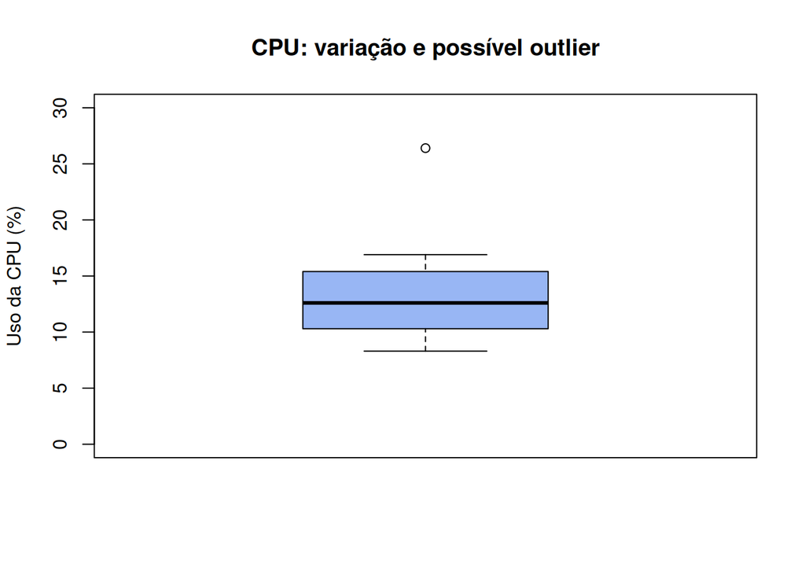

```
## Valores identificados como outliers de CPU (%):
```

```
## [1] 26.4
```

**Análise:** o valor de **26,4%** é identificado como outlier porque está acima do padrão das outras capturas. A região central da amostra vai de 10,3% a 15,4%, com mediana de 12,6%. Embora seja um destaque estatístico, 26,4% não representa, por si só, saturação de CPU.

**Utilidade na dashboard:** sustenta a necessidade de um histórico para investigar picos que o card atual pode deixar de mostrar. Antes de gerar um incidente, é necessário comparar a medição ao parâmetro operacional; a classificação de outlier não deve substituir esse parâmetro.

#### 4.2 RAM

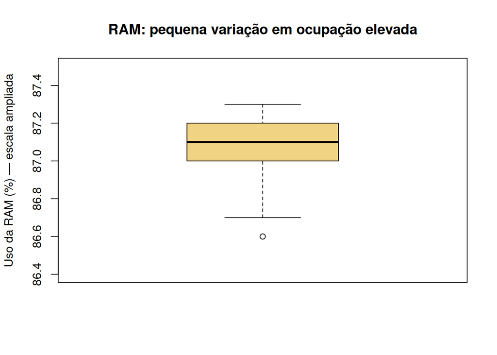

```
## Valores identificados como outliers de RAM (%):
```

```
## [1] 86.6
```

**Análise:** a mediana foi **87,1%** e o desvio padrão aproximadamente **0,24 p.p.**. O valor de 86,6% aparece como outlier inferior devido à pequena dispersão das demais capturas. Isso não indica que uma redução do consumo seja um problema: a regra estatística apenas destaca uma diferença relativa.

**Utilidade na dashboard:** demonstra por que o status não deve depender apenas da variação. É necessário observar também o percentual absoluto de uso e o limite de RAM. Uma memória estável pode continuar muito ocupada, enquanto um ponto fora da caixa pode representar uma pequena redução sem relevância operacional.

#### 4.3 Disco

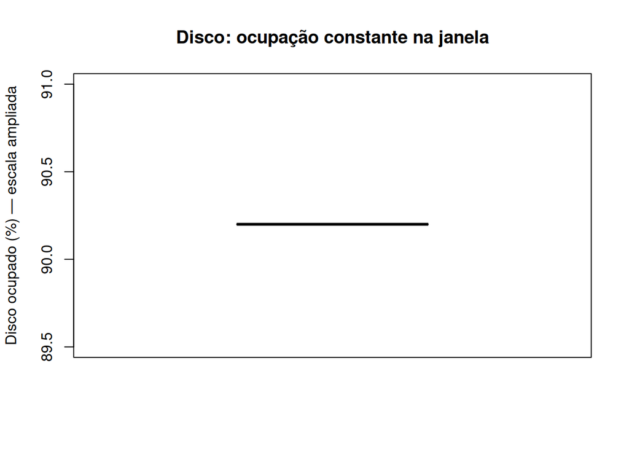

```
## Desvio padrão do disco (p.p.): 0
```

```
## Outliers de disco (%):
```

```
## numeric(0)
```

**Análise:** o boxplot se resume a um traço em **90,2%** porque todos os valores são iguais. O desvio padrão é zero e não existem outliers nesta amostra. Não há problema de execução: a caixa não possui altura quando os quartis coincidem.

**Utilidade na dashboard:** justifica manter a ocupação e o espaço disponível em destaque, mesmo quando a linha histórica fica horizontal. A ausência de variação não significa grande capacidade livre. Este gráfico não mede atividade do disco, taxa de transferência ou tempo de resposta.

### 5. Correlação linear — CPU e RAM aumentam juntas?

Usamos Pearson para descrever a associação linear entre CPU e RAM medidas nos mesmos instantes. O coeficiente `r` varia de -1 a 1. Um valor próximo de zero indica associação linear fraca na amostra, não ausência de qualquer relação possível.

Uma reta com `lm()` será desenhada apenas como apoio visual; não é um modelo validado para previsão. Não calculamos correlação com disco porque ele é constante: sem variação, o coeficiente não é definido.

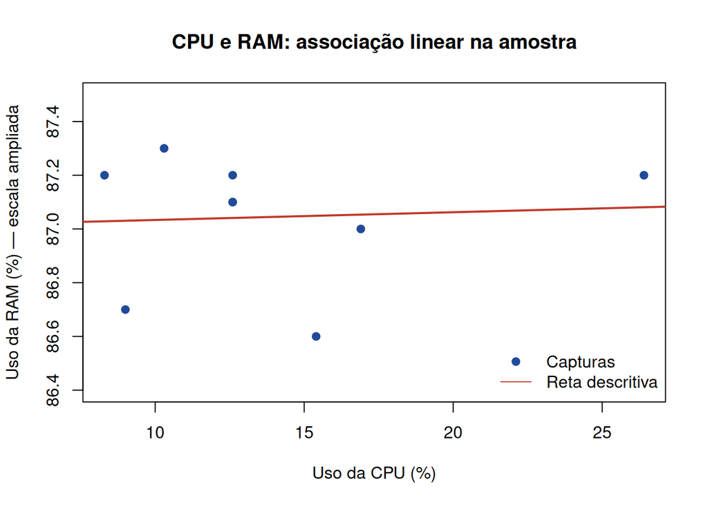

```
## Correlação de Pearson entre CPU e RAM: 0.0658
```

```
## Disco constante: correlações envolvendo DISCO não foram calculadas.
```

**Análise:** a correlação foi **r ≈ 0,0658**, uma associação linear positiva muito fraca, praticamente nula nesta amostra. Os picos de CPU não vieram acompanhados de aumentos proporcionais de RAM. A variação da RAM foi pequena mesmo quando a CPU chegou a 26,4%.

**Utilidade na dashboard:** fundamenta manter indicadores e históricos separados para CPU e RAM, sem usar um como substituto do outro. Comparar os componentes no mesmo período pode orientar a investigação de possíveis sobrecargas. Uma futura visualização de correlação ajudaria a levantar hipóteses de associação, mas **não comprovaria que um componente causa o consumo do outro**.

O resultado não deve ser generalizado: temos nove observações consecutivas, de um único equipamento e uma janela curta. Ele não demonstra independência entre CPU e RAM, nem descarta relações não lineares ou com atraso temporal. A correlação não substitui os gráficos ao longo do tempo.

### 6. Relação com os parâmetros de alerta existentes

O `dash_servidor.js` enviado utiliza limites ilustrativos de **CPU 80%, RAM 75% e disco 75%**. A classificação do JavaScript considera crítico quando o valor é maior ou igual ao limite e atenção a partir de 70% desse limite.

A API/banco, por outro lado, permitem configurar `limite_atencao` e `limite_critico` em `parametro_alerta`. Não devemos presumir que atenção seja sempre 70% do crítico, nem aplicar a este notebook limites dos seeds de outro equipamento.

A tabela seguinte faz somente uma **comparação ilustrativa com os limites do frontend**. Não representa os parâmetros confirmados para o notebook capturado e não conta incidentes reais.

```
##  Componente Limite_ilustrativo_percentual Leituras_no_ou_acima_do_limite
##         CPU                            80                              0
##         RAM                            75                              9
##       DISCO                            75                              9
##  Total_de_leituras
##                  9
##                  9
##                  9
```

**Interpretação:** usando apenas essas referências ilustrativas, a CPU ficou abaixo do limite nas nove capturas; RAM e disco ficaram no ou acima do limite nas nove. Isso evidencia a utilidade de limites específicos por componente e do status junto ao valor de utilização.

**Nove leituras acima do limite não são nove alertas ativos.** As capturas podem pertencer à mesma situação contínua. Contar incidentes ou chamados exige regras de abertura/fechamento, identificação do evento e histórico do sistema/Jira. Não estimamos duração do problema ou quantidade de chamados com esta tabela.

### 7. O que esta análise fundamenta — e o que exige outros dados

| Métrica ou gráfico da dashboard | Contribuição desta análise | Limitação/dado adicional |
| --- | --- | --- |
| Uso atual de CPU e RAM | Última leitura mostra a situação mais recente; distribuições e boxplots contextualizam o valor. | A amostra não valida desempenho de toda a operação. |
| Disco ocupado e espaço disponível | 90,2% ocupado e 9,8% livre mostram por que a capacidade restante precisa aparecer. | Não há tamanho total em GB no CSV nem previsão confiável de esgotamento. |
| Históricos de CPU/RAM/disco com limites | O pico de CPU e a ocupação persistente de RAM/disco justificam preservar a evolução por componente e a referência de alerta. | Histogramas/boxplots não mostram a ordem temporal. O site precisa usar timestamps reais e limites do equipamento. |
| Comparação CPU × RAM | A correlação mostra que acompanhar um componente não substitui medir o outro. | Análise de associação; não é indicador causal ou previsão de falha. Não há gráfico de correlação implementado no frontend enviado. |
| Latência e throughput | Não avaliados neste notebook. | Precisam de medições de rede com unidades e timestamps; os exemplos do frontend não são dados reais da amostra. |
| Servidores ativos, disponibilidade e downtime | Não calculados. CPU baixa/alta não define equipamento online/offline. | Precisam de histórico de verificações de disponibilidade, critérios de estado e duração dos intervalos. |
| Alertas ativos/críticos e incidentes por servidor/componente | A comparação com parâmetros demonstra a função dos limites, não o total de eventos. | Precisam de eventos identificados, equipamento/componente, nível e estado de resolução. |
| Tempo médio de resolução | Não calculado. | Precisa de abertura e resolução de cada incidente concluído; consumo percentual não permite calcular esse tempo. |
| Orçamento anual de indisponibilidade | Não calculado. | Precisa de meta de disponibilidade, período anual definido e duração real das indisponibilidades. |

#### Conclusão

A amostra mostra três comportamentos distintos: **CPU com consumo baixo e um pico relativo**, **RAM com ocupação elevada e pouca variação** e **disco com ocupação elevada e constante**. Essas diferenças fundamentam os cards e históricos separados por componente: um único indicador de “saúde” esconderia informações relevantes.

Os histogramas descrevem as faixas de uso; os boxplots destacam a variação e possíveis valores fora do padrão; a correlação investiga se CPU e RAM acompanham uma à outra. Os limites operacionais continuam sendo configurações do projeto, não conclusões automáticas desses gráficos.

Esta análise oferece uma justificativa exploratória para as métricas de utilização e capacidade, mas não valida sozinha todas as KPIs de serviço. Para ampliar a avaliação, será necessário coletar mais equipamentos e períodos, preservar timestamps e associar as medições aos limites e eventos corretos. Não foram gerados dados sintéticos nem alterados arquivos da aplicação ou do banco.